# R_Circlize包_弦图

### 3.2.11 link方向、箭头及高度调整

弦link有方向属性，就可以增加箭头，有2个参数可以增加箭头  
* `direction.type = "arrows"` 给弦增加带箭头的曲线，曲线位于弦的中心线上，默认给所有弦增加箭头  
* `link.arr.col` 给部分弦增加带箭头的曲线，并指定箭头的颜色，指定方式跟颜色的指定类似, 必须设置`direction.type = "arrows"`参数  
* `link.arr.length` 指定带箭头曲线中，箭头的长度  
* `link.arr.type` 指定箭头类型，可以用`link.arr.type = "big.arrow"` 产生大尺寸箭头，将箭头和箭杆合二为一

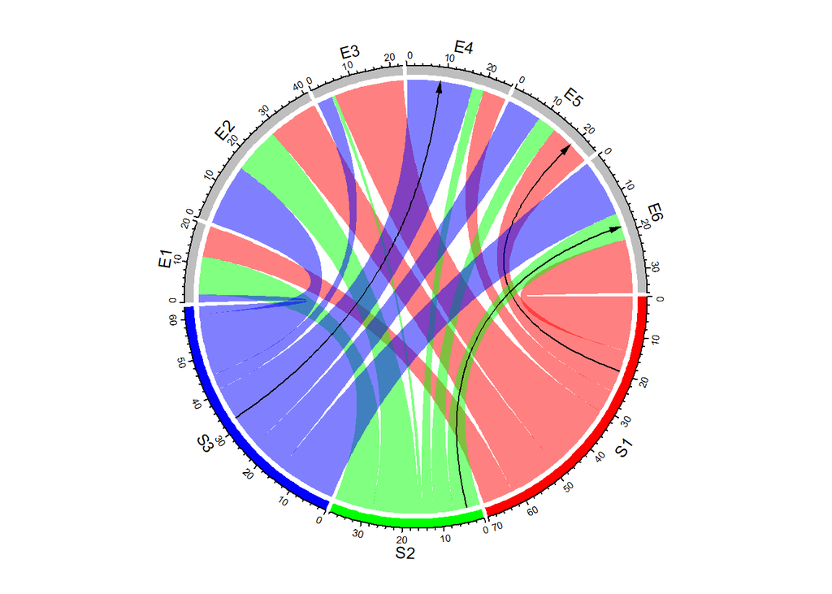

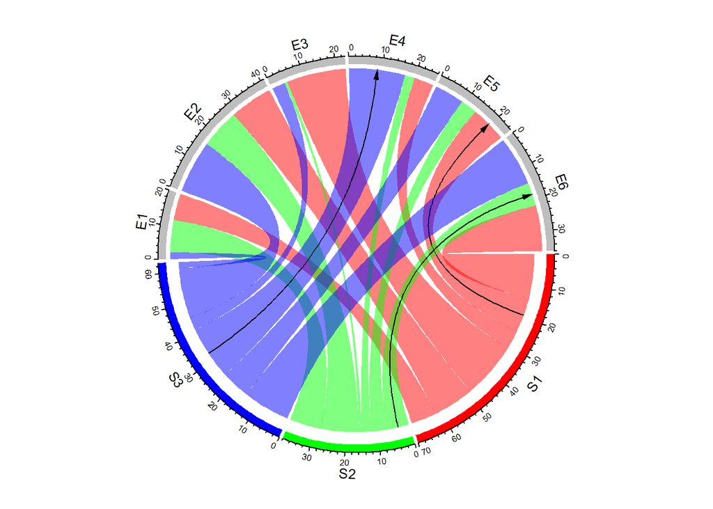

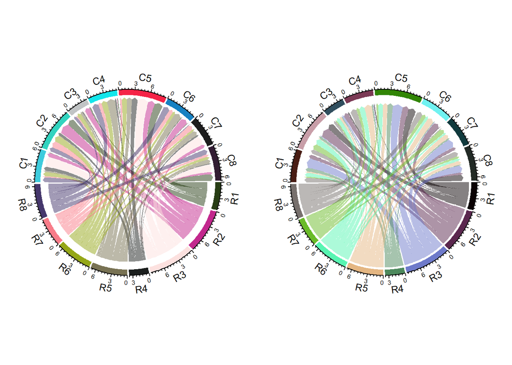

```r
library(circlize)

arr_col <- data.frame(c("S1", "S2", "S3"), c("E5", "E6", "E4"),
                      c("black", "black", "black")) # 生成箭头的颜色3列特征数据框
chordDiagram(mat, grid.col = grid_col, directional = 1,
             link.arr.col = arr_col, direction.type = "arrows", link.arr.length = 0.2)
circos.clear()

# 同时设置箭头和弦高diffHeight
chordDiagram(mat, grid.col = grid_col, directional = 1,
    direction.type = c("diffHeight", "arrows"), # 同时设置箭头和弦高
    link.arr.col = arr_col, link.arr.length = 0.2)
circos.clear()

par(mfrow = c(1, 2))
# 指定箭头类型为大箭头
matx <-  matrix(rnorm(64), 8)

chordDiagram(matx, directional = 1, direction.type = c("diffHeight", "arrows"),
    link.arr.type = "big.arrow") # 大箭头，箭头和箭杆合二为一
circos.clear()

# 大箭头加调整弦高diffHeight
chordDiagram(matx, directional = 1, direction.type = c("diffHeight", "arrows"),
    link.arr.type = "big.arrow", diffHeight = -uh(2, "mm")) # 设置弦高为-2mm
circos.clear()
```